# Blume E-commerce Analytics Case Study

# 5. Customer Retention & Churn

For subscription-based products, retention is really important.

So I explored churn patterns to see how long customers typically stay subscribed and when drop-off happens.

## 5.1 Subscription Churn Analysis

```r
# Churn definition: subscription inactive/canceled after ~60 days
# Using the churned flag from subscriptions data

churn_summary <- subscriptions %>%
  summarize(
    total_subscribers = n(),
    churned_count = sum(churned),
    active_count = sum(!churned),
    churn_rate = mean(churned),
    avg_months_active = mean(months_active),
    median_months_active = median(months_active)
  )

cat("=== Subscription Churn Summary ===\n")
```

```
## === Subscription Churn Summary ===
```

```r
cat("Total subscription customers:", churn_summary$total_subscribers, "\n")
```

```
## Total subscription customers: 918
```

```r
cat("Churned:", churn_summary$churned_count, sprintf("(%.1f%%)\n", churn_summary$churn_rate * 100))
```

```
## Churned: 642 (69.9%)
```

```r
cat("Still Active:", churn_summary$active_count, sprintf("(%.1f%%)\n", (1-churn_summary$churn_rate) * 100))
```

```
## Still Active: 276 (30.1%)
```

```r
cat("Average subscription duration:", round(churn_summary$avg_months_active, 1), "months\n")
```

```
## Average subscription duration: 14.4 months
```

```r
cat("Median subscription duration:", churn_summary$median_months_active, "months\n")
```

```
## Median subscription duration: 10 months
```

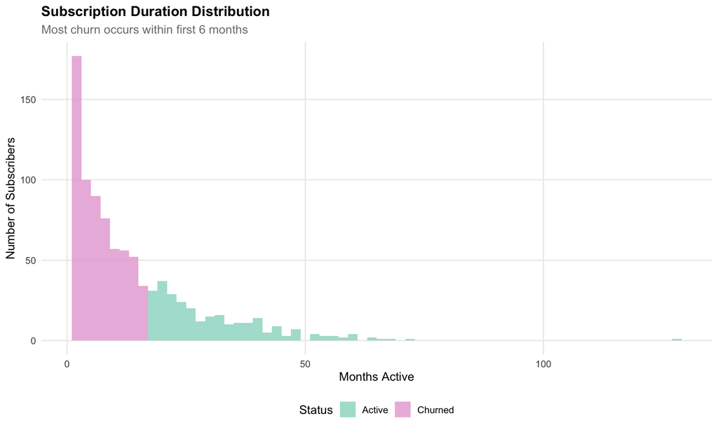

```r
# Distribution of subscription duration
subscriptions %>%
  ggplot(aes(x = months_active, fill = churned)) +
  geom_histogram(binwidth = 2, position = "stack", alpha = 0.8) +
  scale_fill_manual(values = c("TRUE" = blume_colors[2], "FALSE" = blume_colors[4]),
                    labels = c("TRUE" = "Churned", "FALSE" = "Active")) +
  labs(
    title = "Subscription Duration Distribution",
    subtitle = "Most churn occurs within first 6 months",
    x = "Months Active",
    y = "Number of Subscribers",
    fill = "Status"
  )
```

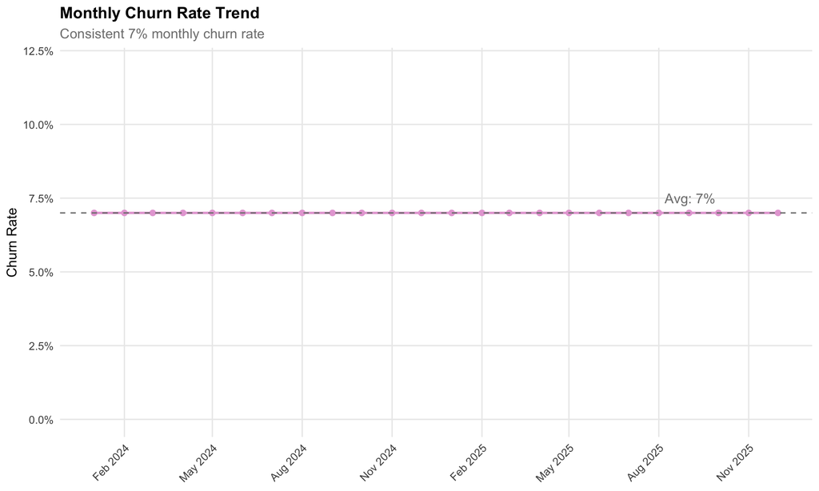

```r
# Monthly churn rate from KPIs
monthly_kpis %>%
  ggplot(aes(x = month, y = churn_rate)) +
  geom_line(color = blume_colors[2], linewidth = 1) +
  geom_point(color = blume_colors[2], size = 2) +
  geom_hline(yintercept = mean(monthly_kpis$churn_rate), linetype = "dashed", color = "gray50") +
  annotate("text", x = max(monthly_kpis$month) - 90, y = 0.075,
           label = "Avg: 7%", color = "gray50") +
  scale_y_continuous(labels = percent_format(), limits = c(0, 0.12)) +
  scale_x_date(date_labels = "%b %Y", date_breaks = "3 months") +
  labs(
    title = "Monthly Churn Rate Trend",
    subtitle = "Consistent 7% monthly churn rate",
    x = NULL,
    y = "Churn Rate"
  ) +
  theme(axis.text.x = element_text(angle = 45, hjust = 1))
```

## 5.2 Cohort Retention Analysis

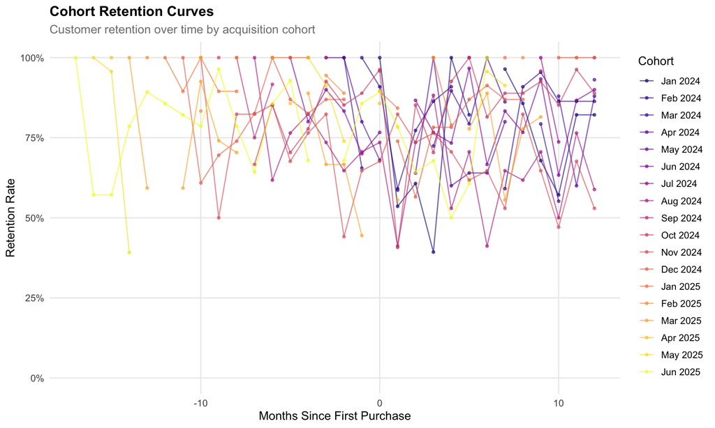

```r
# Create cohorts based on first order month
customers_cohort <- customers %>%
  mutate(cohort_month = floor_date(first_order_date, "month"))

# Join with orders to get order months
cohort_orders <- orders %>%
  left_join(customers_cohort %>% select(customer_id, cohort_month), by = "customer_id") %>%
  filter(!is.na(cohort_month)) %>%
  mutate(
    order_month = floor_date(order_date, "month"),
    months_since_first = interval(cohort_month, order_month) %/% months(1)
  )

# Calculate retention by cohort
cohort_retention <- cohort_orders %>%
  group_by(cohort_month, months_since_first) %>%
  summarize(customers = n_distinct(customer_id), .groups = "drop") %>%
  group_by(cohort_month) %>%
  mutate(
    cohort_size = first(customers),
    retention_rate = customers / cohort_size
  ) %>%
  ungroup()

# Filter for complete cohorts (at least 6 months of data)
recent_cohorts <- cohort_retention %>%
  filter(cohort_month >= "2024-01-01", cohort_month <= "2025-06-01")

# Plot retention curves for recent cohorts
recent_cohorts %>%
  filter(months_since_first <= 12) %>%
  ggplot(aes(x = months_since_first, y = retention_rate, color = factor(cohort_month))) +
  geom_line(alpha = 0.6) +
  geom_point(size = 1, alpha = 0.6) +
  scale_y_continuous(labels = percent_format(), limits = c(0, 1)) +
  scale_color_viridis_d(option = "plasma", labels = function(x) format(as.Date(x), "%b %Y")) +
  labs(
    title = "Cohort Retention Curves",
    subtitle = "Customer retention over time by acquisition cohort",
    x = "Months Since First Purchase",
    y = "Retention Rate",
    color = "Cohort"
  ) +
  theme(legend.position = "right")
```

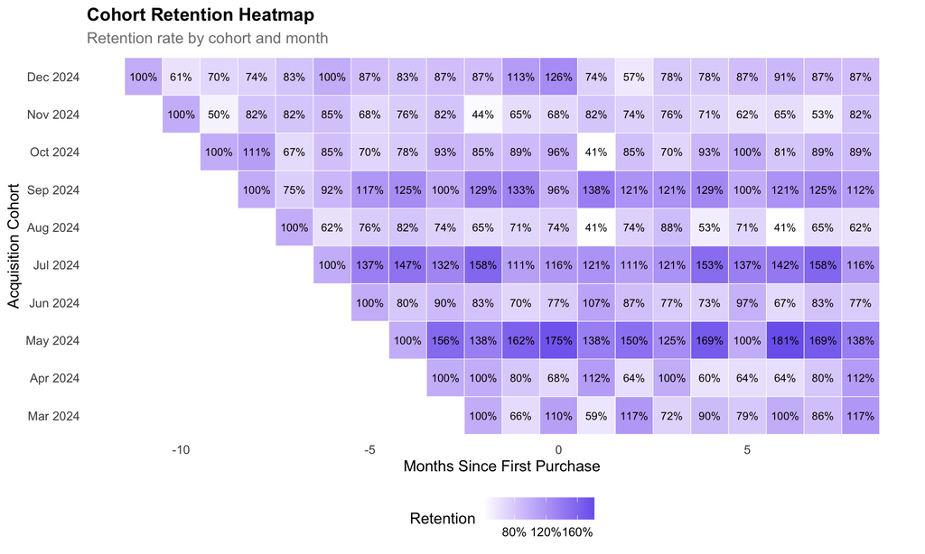

```r
# Cohort retention heatmap (simplified for key cohorts)
cohort_matrix <- recent_cohorts %>%
  filter(months_since_first <= 8, cohort_month >= "2024-03-01", cohort_month <= "2024-12-01") %>%
  select(cohort_month, months_since_first, retention_rate) %>%
  mutate(cohort_label = format(cohort_month, "%b %Y"))

ggplot(cohort_matrix, aes(x = months_since_first, y = reorder(cohort_label, cohort_month),
                          fill = retention_rate)) +
  geom_tile(color = "white") +
  geom_text(aes(label = percent(retention_rate, accuracy = 1)), size = 3) +
  scale_fill_gradient(low = "white", high = blume_colors[1], labels = percent_format()) +
  labs(
    title = "Cohort Retention Heatmap",
    subtitle = "Retention rate by cohort and month",
    x = "Months Since First Purchase",
    y = "Acquisition Cohort",
    fill = "Retention"
  ) +
  theme(panel.grid = element_blank())
```

# 6. Revenue Forecasting

To finish the project, I created a simple 6-month revenue forecast, I used a basic trend + moving average approach that is easy to explain and interpret.

## 6.1 Simple 6-Month Forecast

Using a combination of linear trend and 3-month moving average for a student-friendly forecast.

```r
# Prepare monthly revenue data
monthly_revenue <- monthly_kpis %>%
  select(month, total_revenue) %>%
  mutate(month_num = row_number())

# Linear trend model
trend_model <- lm(total_revenue ~ month_num, data = monthly_revenue)

# Summary
cat("=== Linear Trend Model ===\n")
```

```
## === Linear Trend Model ===
```

```r
cat("Intercept:", dollar(coef(trend_model)[1]), "\n")
```

```
## Intercept: $25,306.47
```

```r
cat("Monthly trend:", dollar(coef(trend_model)[2]), "\n")
```

```
## Monthly trend: $22.41
```

```r
cat("R-squared:", round(summary(trend_model)$r.squared, 4), "\n")
```

```
## R-squared: 0.0097
```

```r
# 3-month moving average for smoothing
monthly_revenue <- monthly_revenue %>%
  mutate(
    ma_3 = zoo::rollmean(total_revenue, k = 3, fill = NA, align = "right"),
    trend_pred = predict(trend_model, .)
  )

# Forecast next 6 months
last_month <- max(monthly_revenue$month)
last_month_num <- max(monthly_revenue$month_num)
last_ma <- tail(na.omit(monthly_revenue$ma_3), 1)

# Simple exponential smoothing weight
alpha <- 0.3

forecast_df <- tibble(
  month = seq(last_month + months(1), by = "month", length.out = 6),
  month_num = (last_month_num + 1):(last_month_num + 6)
) %>%
  mutate(
    trend_forecast = predict(trend_model, newdata = .),
    # Blend trend with recent average (simple approach)
    blended_forecast = alpha * trend_forecast + (1 - alpha) * last_ma,
    forecast_low = blended_forecast * 0.90,
    forecast_high = blended_forecast * 1.10
  )

# Display forecast
forecast_df %>%
  mutate(
    month = format(month, "%b %Y"),
    blended_forecast = dollar(blended_forecast),
    forecast_low = dollar(forecast_low),
    forecast_high = dollar(forecast_high)
  ) %>%
  select(month, blended_forecast, forecast_low, forecast_high) %>%
  kable(
    col.names = c("Month", "Forecast", "Low (90%)", "High (110%)"),
    caption = "6-Month Revenue Forecast (CAD)"
  ) %>%
  kable_styling(bootstrap_options = c("striped", "hover"))
```

6-Month Revenue Forecast (CAD)

| Month | Forecast | Low (90%) | High (110%) |
| --- | --- | --- | --- |
| Jan 2026 | $25,153.69 | $22,638.32 | $27,669.06 |
| Feb 2026 | $25,160.41 | $22,644.37 | $27,676.45 |
| Mar 2026 | $25,167.13 | $22,650.42 | $27,683.85 |
| Apr 2026 | $25,173.86 | $22,656.47 | $27,691.24 |
| May 2026 | $25,180.58 | $22,662.52 | $27,698.64 |
| Jun 2026 | $25,187.30 | $22,668.57 | $27,706.03 |

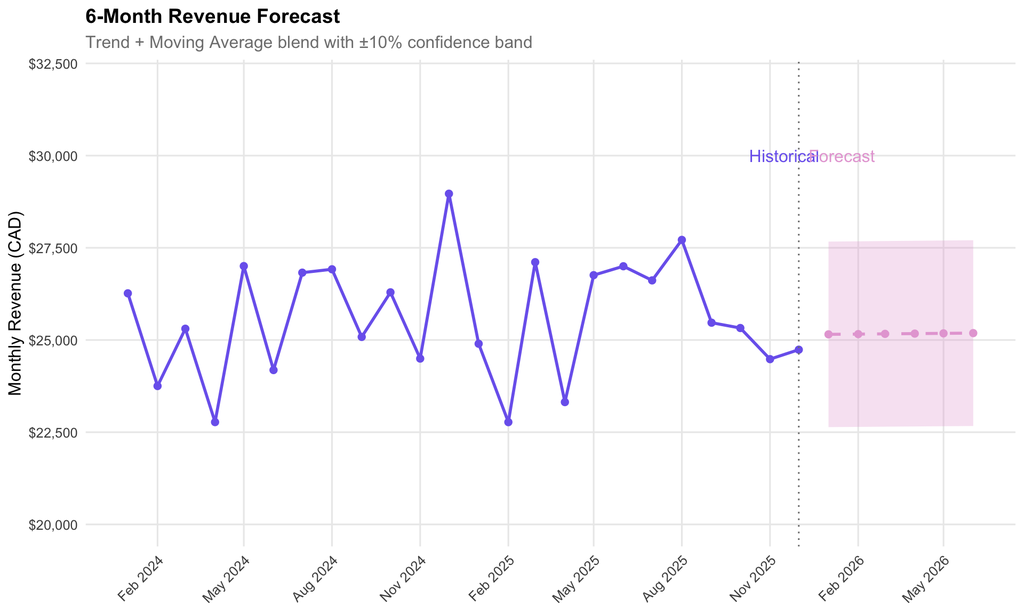

```r
# Combine historical and forecast data
all_data <- bind_rows(
  monthly_revenue %>%
    select(month, total_revenue) %>%
    mutate(type = "Historical"),
  forecast_df %>%
    select(month, blended_forecast, forecast_low, forecast_high) %>%
    rename(total_revenue = blended_forecast) %>%
    mutate(type = "Forecast")
)

# Plot
ggplot() +
  # Historical data
  geom_line(data = filter(all_data, type == "Historical"),
            aes(x = month, y = total_revenue), color = blume_colors[1], linewidth = 1) +
  geom_point(data = filter(all_data, type == "Historical"),
             aes(x = month, y = total_revenue), color = blume_colors[1], size = 2) +
  # Forecast with confidence band
  geom_ribbon(data = forecast_df,
              aes(x = month, ymin = forecast_low, ymax = forecast_high),
              fill = blume_colors[2], alpha = 0.3) +
  geom_line(data = filter(all_data, type == "Forecast"),
            aes(x = month, y = total_revenue), color = blume_colors[2], linewidth = 1, linetype = "dashed") +
  geom_point(data = filter(all_data, type == "Forecast"),
             aes(x = month, y = total_revenue), color = blume_colors[2], size = 2) +
  # Reference lines
  geom_vline(xintercept = last_month, linetype = "dotted", color = "gray50") +
  annotate("text", x = last_month - 15, y = 30000, label = "Historical", color = blume_colors[1]) +
  annotate("text", x = last_month + 45, y = 30000, label = "Forecast", color = blume_colors[2]) +
  scale_y_continuous(labels = dollar_format(), limits = c(20000, 32000)) +
  scale_x_date(date_labels = "%b %Y", date_breaks = "3 months") +
  labs(
    title = "6-Month Revenue Forecast",
    subtitle = "Trend + Moving Average blend with ±10% confidence band",
    x = NULL,
    y = "Monthly Revenue (CAD)"
  ) +
  theme(axis.text.x = element_text(angle = 45, hjust = 1))
```

# 7. Executive Dashboard Summary

## 7.1 KPI Summary Table

Finally, I summarized the main metrics that a business team would likely track each month.

These KPIs help connect the analysis back to real operational decision-making.

```r
# Calculate overall KPIs
overall_kpis <- tibble(
  Metric = c("Total Revenue", "Total Orders", "Average Order Value",
             "Gross Margin %", "Monthly Churn Rate", "Repeat Customer Rate",
             "Subscription Revenue Share"),
  Value = c(
    dollar(sum(monthly_kpis$total_revenue)),
    comma(sum(monthly_kpis$orders)),
    dollar(mean(monthly_kpis$avg_order_value)),
    percent(mean(monthly_kpis$gross_margin_pct)/100, accuracy = 0.1),
    percent(mean(monthly_kpis$churn_rate), accuracy = 0.1),
    percent(repeat_rate, accuracy = 0.1),
    percent(sum(monthly_kpis$subscription_revenue) / sum(monthly_kpis$total_revenue), accuracy = 0.1)
  )
)

overall_kpis %>%
  kable(caption = "Executive KPI Summary (24 Months)") %>%
  kable_styling(bootstrap_options = c("striped", "hover"), full_width = FALSE) %>%
  row_spec(0, bold = TRUE, color = "white", background = blume_colors[1])
```

Executive KPI Summary (24 Months)

| Metric | Value |
| --- | --- |
| Total Revenue | $614,078 |
| Total Orders | 15,000 |
| Average Order Value | $40.94 |
| Gross Margin % | 59.1% |
| Monthly Churn Rate | 7.0% |
| Repeat Customer Rate | 96.7% |
| Subscription Revenue Share | 18.4% |

## 7.2 Monthly KPI Trend Dashboard

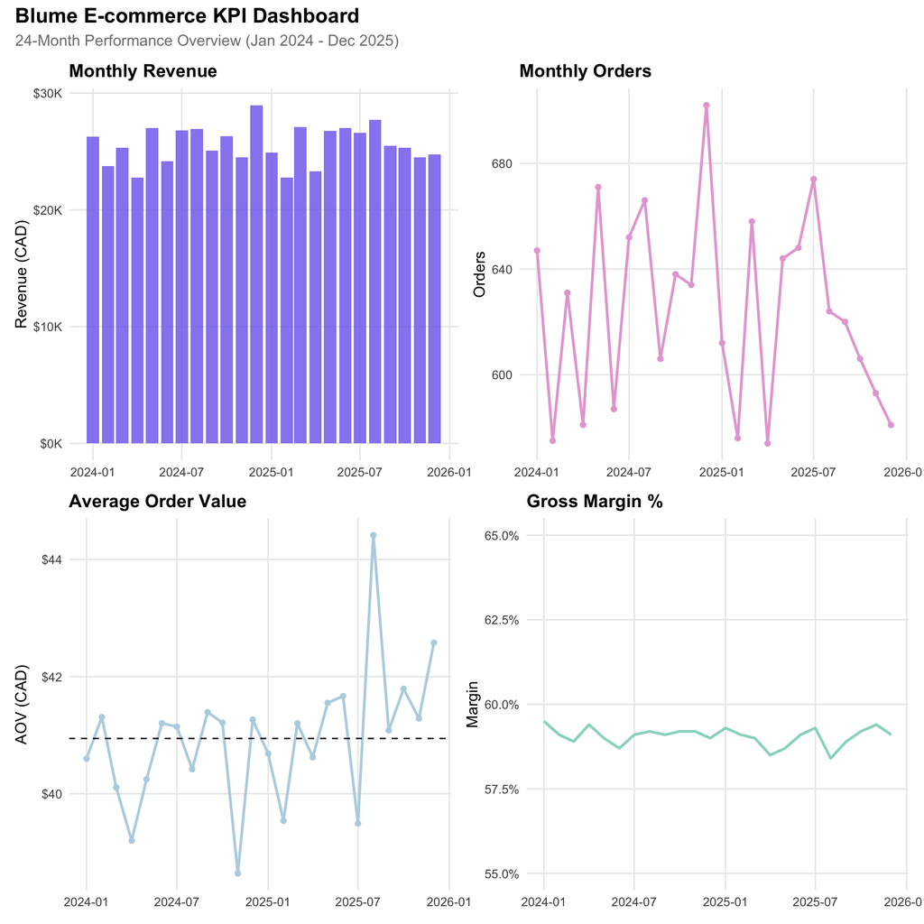

```r
# Create a multi-panel dashboard
p1 <- ggplot(monthly_kpis, aes(x = month, y = total_revenue)) +
  geom_col(fill = blume_colors[1], alpha = 0.8) +
  scale_y_continuous(labels = dollar_format(scale = 0.001, suffix = "K")) +
  labs(title = "Monthly Revenue", x = NULL, y = "Revenue (CAD)")

p2 <- ggplot(monthly_kpis, aes(x = month, y = orders)) +
  geom_line(color = blume_colors[2], linewidth = 1) +
  geom_point(color = blume_colors[2]) +
  labs(title = "Monthly Orders", x = NULL, y = "Orders")

p3 <- ggplot(monthly_kpis, aes(x = month, y = avg_order_value)) +
  geom_line(color = blume_colors[3], linewidth = 1) +
  geom_point(color = blume_colors[3]) +
  geom_hline(yintercept = mean(monthly_kpis$avg_order_value), linetype = "dashed") +
  scale_y_continuous(labels = dollar_format()) +
  labs(title = "Average Order Value", x = NULL, y = "AOV (CAD)")

p4 <- ggplot(monthly_kpis, aes(x = month, y = gross_margin_pct/100)) +
  geom_area(fill = blume_colors[4], alpha = 0.5) +
  geom_line(color = blume_colors[4], linewidth = 1) +
  scale_y_continuous(labels = percent_format(), limits = c(0.55, 0.65)) +
  labs(title = "Gross Margin %", x = NULL, y = "Margin")

# Combine plots
library(patchwork)
(p1 + p2) / (p3 + p4) +
  plot_annotation(
    title = "Blume E-commerce KPI Dashboard",
    subtitle = "24-Month Performance Overview (Jan 2024 - Dec 2025)",
    theme = theme(plot.title = element_text(face = "bold", size = 16))
  )
```

**Key Insight:** Overall, Blume’s revenue is driven by a mix of best-selling single products and higher-value bundles, with subscriptions providing an additional recurring base.

Tracking AOV, churn, and gross margin together gives a clearer picture of growth and sustainability.

# 8. Key Findings & Recommendations

## Summary of Insights

[output not shown]

## Limitations

This project uses simulated transaction data based on real Blume product pricing and general ecommerce benchmarks.

Because Blume’s internal cost structure, marketing spend, and true customer behavior aren’t publicly available, results should be viewed as educational rather than financial reporting.